# Teresa Masciopinto

JUNIOR DATA ANALYST

- Learn more

Laureata in Economia e Management, di recente ho completato il programma "Google Data Analytics" (riconosciuto dall'American Council on Education).

Amo riconoscere collegamenti e pattern tra i dati, attraverso il linguaggio di programmazione e la statistica. Mi piacerebbe aiutare le organizzazioni a raggiungere i loro obiettivi, attraverso la comprensione di metriche e visualizzazioni in grado di raccontare i dati.

Bari, 2023

e-mail: teresamasciopinto1@gmail.com

LinkedIn: https://www.linkedin.com/in/teresa-masciopinto-210342285/

## Progetti

| title: “Progetto_Craiglist” |
| --- |
| author: “Teresa Masciopinto” |
| date: ‘2023’ |
| output: html_document |

## Progetto Craiglist

#### Il seguente report presenta un’analisi statistica approfondita dei veicoli usati d’epoca in vendita sulla piattaforma [Craiglist](https://geo.craigslist.org/iso/us), area geografica degli Stati Uniti.

[Dati grezzi](https://www.kaggle.com/datasets/austinreese/craigslist-carstrucks-data)

*Librerie scaricate*

- library(readr)
- library(tidyverse)
- library(dplyr)
- library(tidyr)
- library(csv)
- library(janitor)
- library(ggplot2)
- library(skimr)
- library(plyr)
- library(ggthemes)
- library(car)

*Importo il dataset e lo ispeziono al fine di comprendere i dati, valutare la presenza di errori nei valori unici e condurre la mia analisi*

`dataset <- read_delim("C:/Users/Utente/Desktop/Used Cars Project/Used_cars_01.csv", delim = ";", escape_double = FALSE, trim_ws = TRUE)`

- unique(dataset$region)
- unique(dataset$year)
- unique(dataset$manufacturer)
- unique(dataset$model)
- unique(dataset$condition)
- unique(dataset$cylinders)
- unique(dataset$fuel)
- unique(dataset$title_status)
- unique(dataset$drive)
- unique(dataset$type)
- unique(dataset$paint_color)
- unique(dataset$transmission)

*Importo i dati in ambiente BigQuery per manipolarli con linguaggio SQL e creare una tabella di riferimento in linea con le richieste aziendali*

*Interpretazione tabella:* *Per ogni anno di immatricolazione, è indicata la tipologia di veicolo con il numero maggiore di inserzioni di vendita. I veicoli sono ordinati in ordine di prezzo, di cui e sono selezionati solo quelli in buono/ottimo stato. È indicata la casa di produzione, cilindrata e altre caratteristiche principali*

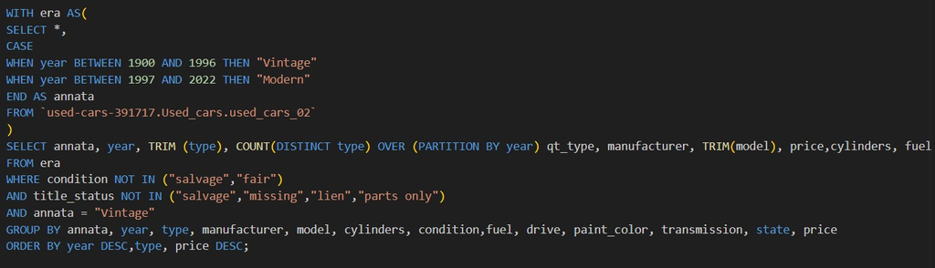

BigQuery SQL

#### Preparazione dei dati per l’analisi.

`vintage$price <- as.numeric(vintage$price)` `str(vintage$price)`

`cleaned_head <- clean_names(vintage)`

`filtered <- cleaned_head %>%` `select( year, manufacturer, qt_type, f0, f1, condition, price, cylinders, fuel, drive, transmission,` `paint_color, state) %>%` `filter(complete.cases(year,manufacturer, f1,f0,price,condition))`

`colonne_con_null <- colnames(filtered)[colSums(is.na(filtered)) > 0]`

`filtered_02 <- filtered %>%` `filter(filtered$price > 400)` `filtered_02 %>%` `arrange(price)`

`z <- filtered_02 %>%` `group_by(f0) %>%` `mutate(z_scores = (price - mean(price, na.rm = TRUE)) / sd(price, na.rm = TRUE))`

`possib_outl <- z %>% filter(z_scores > '2')`

#### Analisi dei dati

`mean_price <- filtered_02 %>% group_by(f0) %>% reframe(mean_price = mean(price)) %>% arrange(desc(mean_price))`

```r
mean_price
```

```
## # A tibble: 13 × 2
##    f0          mean_price
##    <chr>            <dbl>
##  1 convertible     19890.
##  2 other           18079.
##  3 coupe           17943.
##  4 bus             16674.
##  5 wagon           13141.
##  6 offroad         12237.
##  7 pickup          12075.
##  8 van             11932.
##  9 truck           11610.
## 10 SUV             11236.
## 11 mini-van        10176.
## 12 sedan            9898.
## 13 hatchback        9100.
```

*Raggruppando per anno, noto che le auto convertibili più costose appartengono agli anni ’50*

`conv <- filtered_02 %>%` `group_by(year, f0) %>%` `reframe(mean_price = mean(price)) %>%` `arrange(desc(mean_price))`

```
## # A tibble: 529 × 3
##     year f0          mean_price
##    <dbl> <chr>            <dbl>
##  1  1959 convertible    143750
##  2  1913 convertible     85000
##  3  1954 convertible     74950
##  4  1957 wagon           62000
##  5  1957 other           59449.
##  6  1992 other           57000
##  7  1955 wagon           54000
##  8  1962 convertible     52366.
##  9  1940 truck           49500
## 10  1961 convertible     49500.
## # ℹ 519 more rows
```

#### Statistiche

`skim <- filtered_02 %>%` `group_by(f0) %>%` `skim_without_charts(price)`

Data summary

| Name | Piped data |
| --- | --- |
| Number of rows | 4230 |
| Number of columns | 13 |
| _______________________ |  |
| Column type frequency: |  |
| numeric | 1 |
| ________________________ |  |
| Group variables | f0 |

**Variable type: numeric**

| skim_variable | f0 | n_missing | complete_rate | mean | sd | p0 | p25 | p50 | p75 | p100 |
| --- | --- | --- | --- | --- | --- | --- | --- | --- | --- | --- |
| price | SUV | 0 | 1 | 11236.04 | 11512.23 | 850 | 4050.0 | 7950 | 13974.25 | 95000 |
| price | bus | 0 | 1 | 16673.63 | 9006.39 | 3200 | 9250.0 | 16500 | 22900.00 | 35000 |
| price | convertible | 0 | 1 | 19889.55 | 21007.71 | 1200 | 8400.0 | 14000 | 23428.00 | 150000 |
| price | coupe | 0 | 1 | 17943.32 | 16242.88 | 900 | 7500.0 | 13500 | 23500.00 | 150000 |
| price | hatchback | 0 | 1 | 9099.76 | 6511.79 | 500 | 4450.0 | 8000 | 10000.00 | 35000 |
| price | mini-van | 0 | 1 | 10175.68 | 9324.41 | 1000 | 3412.5 | 5750 | 14500.00 | 32500 |
| price | offroad | 0 | 1 | 12236.53 | 10214.05 | 600 | 6500.0 | 8500 | 14999.25 | 60000 |
| price | other | 0 | 1 | 18079.35 | 17781.49 | 1200 | 7950.0 | 12500 | 22500.00 | 109000 |
| price | pickup | 0 | 1 | 12074.79 | 9459.25 | 650 | 5500.0 | 9500 | 16000.00 | 90000 |
| price | sedan | 0 | 1 | 9897.55 | 10277.18 | 599 | 3300.0 | 6700 | 12500.00 | 99888 |
| price | truck | 0 | 1 | 11609.91 | 11468.79 | 800 | 5000.0 | 8500 | 14000.00 | 119999 |
| price | van | 0 | 1 | 11931.89 | 9024.32 | 920 | 4000.0 | 10450 | 16375.00 | 41000 |
| price | wagon | 0 | 1 | 13141.25 | 17687.50 | 1200 | 3950.0 | 6500 | 15000.00 | 99000 |

#### Sommario variabile quantitativa e differenza interquartile

```
##    Min. 1st Qu.  Median    Mean 3rd Qu.    Max.
##     500    5500    9900   14072   17500  150000
```

```
## [1] 12000
```

#### Modali

`modali <- filtered_02 %>%` `group_by(f0) %>%` `reframe(mean_price = mean(price),` `mode_manufacturer = names(table(manufacturer))[which.max(table(manufacturer))],` `mode_manufacturer_fuel = names(table(fuel))[which.max(table(fuel))],` `mode_manufacturer_transmission = names(table(transmission))[which.max(table(transmission))],` `mode_manufacturer_cylinders = ifelse(length(table(cylinders)) == 0, NA,` `names(table(cylinders))[which.max(table(cylinders))]),` `mode_manufacturer_drive = names(table(drive))[which.max(table(drive))],` `mode_manufacturer_color = names(table(paint_color))[which.max(table(paint_color))],` `mode_manufacturer_drive = names(table(drive))[which.max(table(drive))]) %>%` `arrange(desc(mean_price))`

```r
knitr::kable(modali, format = "markdown")
```

| f0 | mean_price | mode_manufacturer | mode_manufacturer_fuel | mode_manufacturer_transmission | mode_manufacturer_cylinders | mode_manufacturer_drive | mode_manufacturer_color |
| --- | --- | --- | --- | --- | --- | --- | --- |
| convertible | 19889.546 | ford | gas | automatic | 8 cylinders | rwd | red |
| other | 18079.350 | chevrolet | gas | automatic | 8 cylinders | rwd | white |
| coupe | 17943.325 | chevrolet | gas | automatic | 8 cylinders | rwd | red |
| bus | 16673.632 | volkswagen | gas | manual | 4 cylinders | rwd | blue |
| wagon | 13141.246 | chevrolet | gas | automatic | 8 cylinders | rwd | white |
| offroad | 12236.534 | jeep | gas | manual | 6 cylinders | 4wd | red |
| pickup | 12074.787 | chevrolet | gas | automatic | 8 cylinders | rwd | blue |
| van | 11931.892 | volkswagen | gas | automatic | 4 cylinders | rwd | white |
| truck | 11609.907 | ford | gas | automatic | 8 cylinders | rwd | white |
| SUV | 11236.039 | jeep | gas | automatic | 6 cylinders | 4wd | white |
| mini-van | 10175.682 | mitsubishi | gas | automatic | 4 cylinders | 4wd | black |
| sedan | 9897.552 | ford | gas | automatic | 8 cylinders | rwd | white |
| hatchback | 9099.758 | chevrolet | gas | automatic | 8 cylinders | rwd | red |

##### Automobili più e meno costose del dataset (di cui sono disponibili i dati di interesse)

`riga_prezzo_massimo <- filtered_02[which.max(filtered_02$price), ]`

`riga_prezzo_minimo <- filtered_02[which.min(filtered_02$price), ]`

`unione <- rbind(riga_prezzo_massimo, riga_prezzo_minimo)`

```r
knitr::kable(unione, format = "markdown")
```

| year | manufacturer | qt_type | f0 | f1 | condition | price | cylinders | fuel | drive | transmission | paint_color | state |
| --- | --- | --- | --- | --- | --- | --- | --- | --- | --- | --- | --- | --- |
| 1969 | porsche | 10 | coupe | 911 s | excellent | 150000 | 6 cylinders | gas | rwd | manual | yellow | ny |
| 1990 | toyota | 11 | hatchback | tercel | good | 500 | 4 cylinders | gas | fwd | manual | blue | ca |

## Analisi di regressione.

#### Risultato analisi:

Come possiamo notare dal grafico a dispersione, l’associazione tra le variabili è tutt’altro che lineare, nonostante i prezzi più bassi siano effettivamente registrati in anni più recenti. Per il set di dati considerato, la probabilità di ottenere il t-value osservato, sia per intercetta che i coefficenti di regressione, è bassa, dunque il test di correlazione è estremamente significativo. I coefficenti mostrano effettivamente correlazione negativa tra la variabile prezzo e decadi più recenti. La percentuale di prezzo spiegata dal modello è del 18.41 %. Questo significa che il prezzo è fortemente influenzato da altre variabili non incluse nel modello. Il valore di R quadro corretto, mostra come nel modello non ci siano variabili ridondanti che sovrastimano la sua capacità esplicativa.

Al fine di verificare la capacità del modello di catturare correttamente gli effetti delle variabili, è testata la normalità dei residui (tramite il grafico quantile-quantile e il test di Shapiro-Wilk), l’omoschedasticità, l’assenza di autocorrelazione (Durbin-Watson). Tutti i test risultano estremamenti significativi, considerando un livello di significatività del 5%. Infine, il test di collinearità in questo caso non è utile in quanto i regressori del modello sono trattati come variabili dummy e non causano dipendenza indesiderata tra le variabili. *

*Modello i dati al fine di renderli utilizzabili per l’analisi di regressione.*

`regressione_frame <- cleaned_data %>%` `mutate(decades = case_when(` `year >= 1900 & year < 1960 ~ "1900-1960",` `year >= 1960 & year < 1970 ~ "1960-1969",` `year >= 1970 & year < 1980 ~ "1970-1979",` `year >= 1980 & year < 1990 ~ "1980-1989",` `year >= 1990 & year <= 1996 ~ "1990-1996",` `TRUE ~ as.character(year)` `))`

```r
lm(price ~  decades, data = regressione_frame) %>%
  summary()
```

```
##
## Call:
## lm(formula = price ~ decades, data = regressione_frame)
##
## Residuals:
##    Min     1Q Median     3Q    Max
## -23774  -6510  -2548   3326 127452
##
## Coefficients:
##                  Estimate Std. Error t value Pr(>|t|)
## (Intercept)       26674.4      631.0  42.274  < 2e-16 ***
## decades1960-1969  -4126.3      845.1  -4.883 1.08e-06 ***
## decades1970-1979 -10483.8      800.6 -13.094  < 2e-16 ***
## decades1980-1989 -16044.0      758.0 -21.167  < 2e-16 ***
## decades1990-1996 -17664.8      710.2 -24.874  < 2e-16 ***
## ---
## Signif. codes:  0 '***' 0.001 '**' 0.01 '*' 0.05 '.' 0.1 ' ' 1
##
## Residual standard error: 13040 on 4225 degrees of freedom
## Multiple R-squared:  0.1841, Adjusted R-squared:  0.1833
## F-statistic: 238.3 on 4 and 4225 DF,  p-value: < 2.2e-16
```

#### VERIFICA DELLE ASSUNZIONI DEL MODELLO.

- I grafici mostrano la correlazione tra la variabile price e la decade di riferimento. *

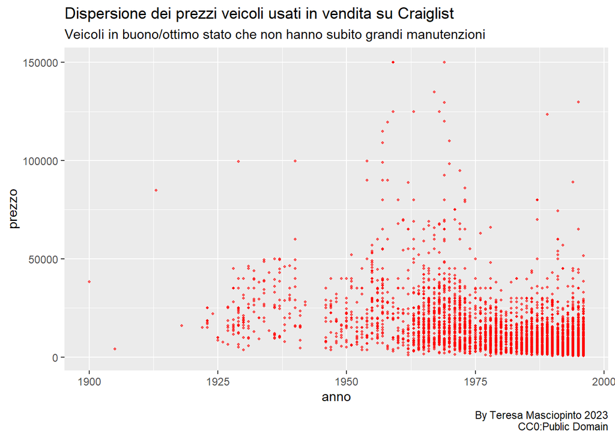

```r
ggplot(data = regressione_frame) +
  geom_point(mapping = aes(y = price, x = year), color = "red", size = 0.7, alpha = 0.6)+
  labs(x = "anno", y = "prezzo", title ="Dispersione dei prezzi veicoli usati in vendita su Craiglist", subtitle ="Veicoli in buono/ottimo stato che non hanno subito grandi manutenzioni", caption = "By Teresa Masciopinto 2023\nCC0:Public Domain")
```

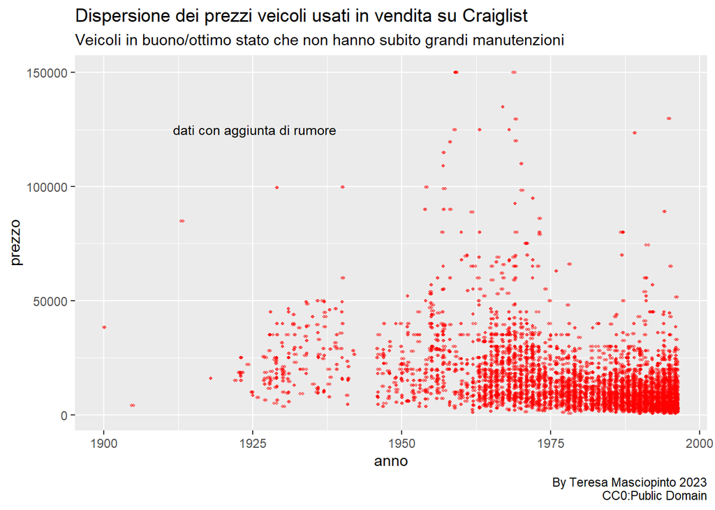

```r
ggplot(data = regressione_frame) +
  geom_point(mapping = aes(y = price, x = year), color = "red", size = 0.7, alpha = 0.4)+
  geom_jitter(mapping = aes(y = price, x = year), color = "red", size = 0.7, alpha = 0.4)+
  labs(x = "anno", y = "prezzo", title ="Dispersione dei prezzi veicoli usati in vendita su Craiglist", subtitle ="Veicoli in buono/ottimo stato che non hanno subito grandi manutenzioni", caption = "By Teresa Masciopinto 2023\nCC0:Public Domain")+
  annotate(geom = "text", x = 1925, y = 125000, label = " dati con aggiunta di rumore",size = 3.3)
```

#### Normalità dei residui

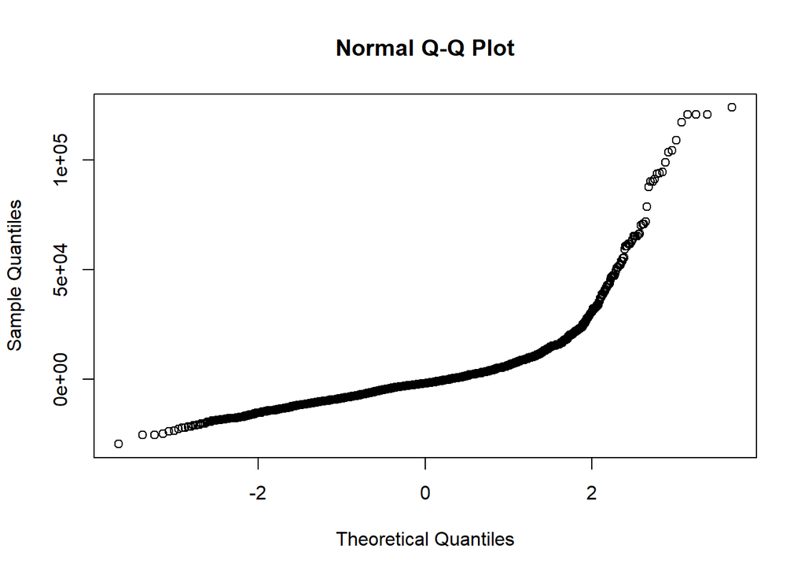

```r
residui <- residuals.lm(modello)
qqnorm(residui)
```

```r
##TEST DI SHAPIRO WILK

testsh <- shapiro.test(residuals.lm(mod))
testsh
```

```
##
##  Shapiro-Wilk normality test
##
## data:  residuals.lm(mod)
## W = 0.722, p-value < 2.2e-16
```

#### Durbin-Watson Test

```r
modello <-lm(price ~  decades, data = regressione_frame) %>%
summary()
dwtest(modello)
```

```
##
##  Durbin-Watson test
##
## data:  modello
## DW = 1.0811, p-value < 2.2e-16
## alternative hypothesis: true autocorrelation is greater than 0
```

#### Grafico della dispersione dei residui

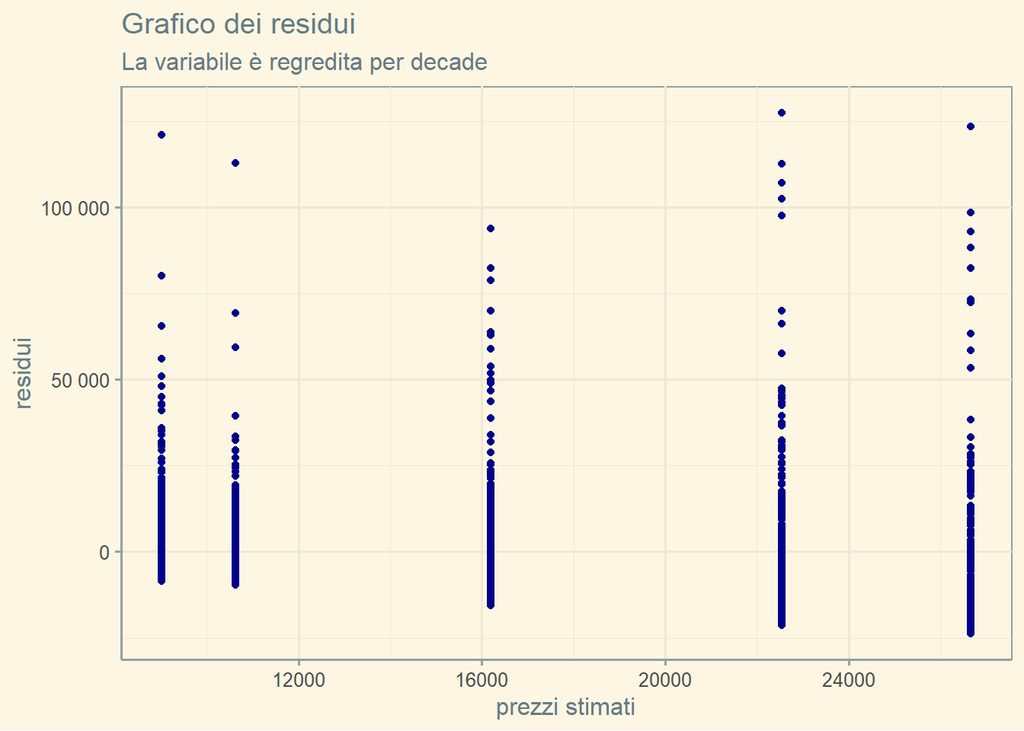

```r
regress_decades <-lm(price ~decades, data = regressione_frame)

residui_01 <- resid(regress_decades)
valori_predetti_01 <- fitted(regress_decades)  # Ottieni i valori predetti dal modello

ggplot(data = regress_decades) +
  geom_point(aes(x = valori_predetti_01, y = residui_01), color = "darkblue") +
  scale_y_continuous(labels = scales::number_format()) +
  labs(title = "Grafico dei residui", subtitle = "La variabile è regredita per decade", x = "prezzi stimati", y = "residui")+
  theme_solarized()
```

*Preparo i dati per le visualizzazioni. Al fine di rendere il grafico meno dettagliato ai fini di visualizzazione chiara e rappresentativa, filtro i dati al fine di ottenere le modalità più frequenti della variabile “manufacturer”.*

```r
filtered_for_chart <- filtered_02[filtered_02$manufacturer %in% names(table(filtered_02$manufacturer))[table(filtered_02$manufacturer) > 150],]
filtered_for_chart
```

```
## # A tibble: 2,806 × 13
##     year manufacturer qt_type f0    f1     condition price cylinders fuel  drive
##    <dbl> <chr>          <dbl> <chr> <chr>  <chr>     <dbl> <chr>     <chr> <chr>
##  1  1996 ford              13 SUV   bronc… excellent 29500 8 cylind… gas   4wd
##  2  1996 ford              13 SUV   bronco excellent 24250 8 cylind… gas   4wd
##  3  1996 toyota            13 SUV   land … excellent 22000 6 cylind… gas   4wd
##  4  1996 chevrolet         13 SUV   tahoe  like new  16000 8 cylind… gas   4wd
##  5  1996 ford              13 SUV   bronco excellent 15500 8 cylind… gas   fwd
##  6  1996 toyota            13 SUV   hilux… excellent 13900 4 cylind… gas   4wd
##  7  1996 toyota            13 SUV   rav4   excellent 10900 4 cylind… gas   4wd
##  8  1996 jeep              13 SUV   chero… excellent  8995 4 cylind… gas   rwd
##  9  1996 jeep              13 SUV   chero… excellent  8995 <NA>      gas   <NA>
## 10  1996 jeep              13 SUV   chero… good       7500 6 cylind… gas   fwd
## # ℹ 2,796 more rows
## # ℹ 3 more variables: transmission <chr>, paint_color <chr>, state <chr>
```

```r
unique(filtered_for_chart$manufacturer)
```

```
## [1] "ford"          "toyota"        "chevrolet"     "jeep"
## [5] "mercedes-benz"
```

```r
write.csv(filtered_for_chart, file = "Principali case di produzione.csv")
```

#### GRAFICI A BARRE

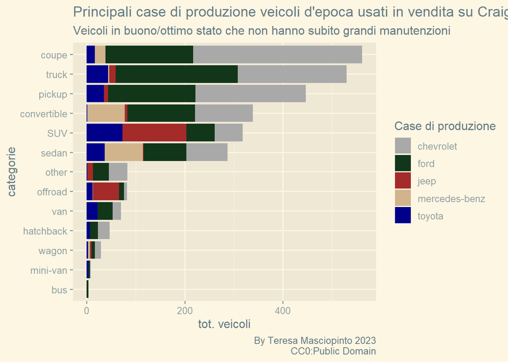

```r
ggplot(data = filtered_for_chart) +
  geom_bar(mapping = aes(x = fct_reorder(f0, f0, .fun = length) ,fill = manufacturer)) +
  labs(x = "categorie", y = "tot. veicoli", title ="Principali case di produzione veicoli d'epoca usati in vendita su Craiglist", subtitle ="Veicoli in buono/ottimo stato che non hanno subito grandi manutenzioni", caption = "By Teresa Masciopinto 2023\nCC0:Public Domain") +
  theme(axis.text.x = element_text(angle = 0), axis.text.y = element_text(angle = 360))+
  scale_fill_manual(values = c( "darkgrey",
                                "#123619",
                                "brown",  "#D2B48C",  "darkblue")) +
  coord_flip() +
  theme_solarized_2() +
  guides(guides(fill = guide_legend(title = "Case di produzione")))
```

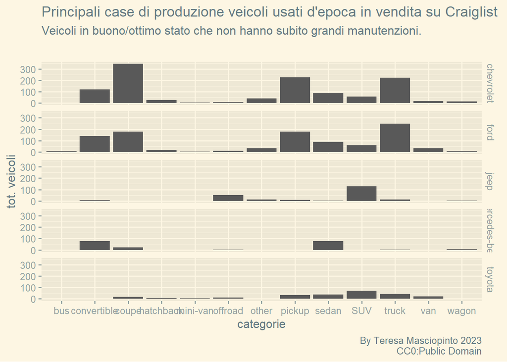

```r
ggplot(data = filtered_for_chart) +
  geom_bar(mapping = aes(x = f0)) +
  labs(x = "categorie", y = "tot. veicoli", title ="Principali case di produzione veicoli usati d'epoca in vendita su Craiglist", subtitle = "Veicoli in buono/ottimo stato che non hanno subito grandi manutenzioni.", caption = "By Teresa Masciopinto 2023\nCC0:Public Domain") +
  theme(axis.text.x = element_text(angle = 90)) +
  facet_grid(manufacturer~"") +
  theme_solarized_2()
```

#### ISTOGRAMMA

[figure not shown]

```r
  filtered_02%>%
  ggplot(aes(x = price)) +
  geom_histogram(binwidth = 10000, fill = "#8B4513", col = "black") +
  labs(x = "Fasce di prezzo", y = "Frequenze", title = "Istogramma delle frequenze per fasce di prezzo", subtitle = "Veicoli d'epoca usati su Craiglist in buono/ottimo stato che non hanno subito grandi manutenzioni.", caption = "By Teresa Masciopinto 2023\nCC0:Public Domain") +
  annotate(geom = "text", x = 100000, y = 500, label = "Ampiezze pari a $10.000", col = "darkgrey", size = 5.3) +
  theme_solarized_2()
```

## È possibile che i dati non vengano mostrati correttamente. Prego di accedere a Tableau per una visualizzazione corretta del cruscotto.

[figure not shown]